# Ecosystem Service Flood Control | Norway

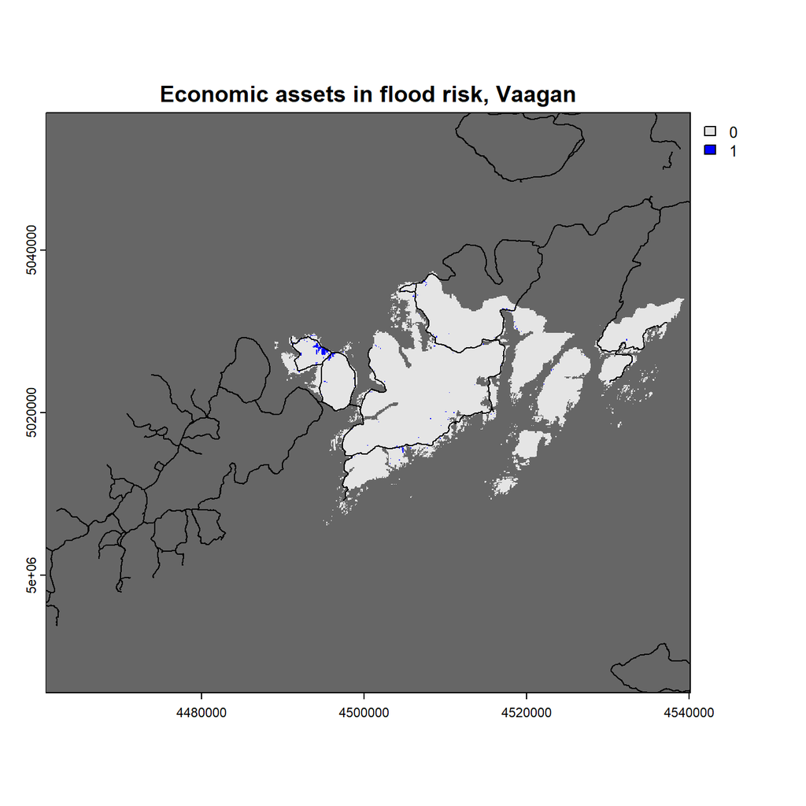

```r
# Vågan
plot(sdam_econ %>% crop(vas,mask=T),col=ccsdam,colNA="grey40",
     main="Economic assets in flood risk, Vaagan")
plot(var,add=T)
```

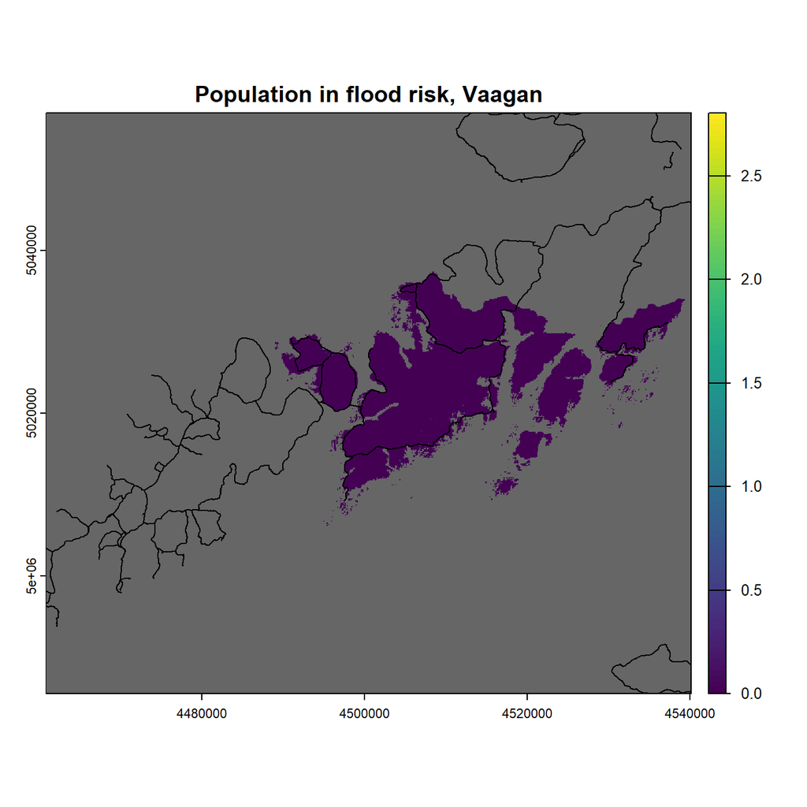

```r
plot(sdam_pop %>% crop(vas,mask=T),colNA="grey40",
     main="Population in flood risk, Vaagan")
plot(var,add=T)
```

```r
# clean up
rm(ccsdam)
gc()
```

# 5. Service Flow SPA –> SDA

## 5.1 Introduction

Now the service flow is quantified at the level of the SDAs. We calculate it for each SDA gridcell as the ratio of upstream surface area that is covered by SPA. Upstream surface area is the area from which we expect water to flow - so this requires slope information.

NB: the guidance suggests to use all upstream area for this, irrespective of political boundaries. For the time being we limit ourselves to Norway as service providing area, but could include neighbouring countries as well if we want.

The calculation of service flow is straightforward using the built-in functions of R’s terra package. First, we compute the number of upstream cells for each SDA cell. Second, we compute the proportion of these upstream cells that are covered by SPA (of various kind). The service flow is then equal to the ratio of upstream cells covered by SPA over all upstream cells.

Example: If the the ratio is 1, then all upstream cells of a service demanding cell are covered by SPA, hence “flood controlled by the ecosystem”. If the ratio is 0, then none of the upstream cells of a service demanding cell are covered b y SPA, hence “not flood controlled by the ecosystem”.

Important to note here is that when there is no unique flow direction to identify from the slope data, then terra will allocate the flow direction randomly. This is not ideal, but at least we can make terra return unique results by setting seeds for the random sequence generator.

## 5.2 Flow Accumulation

First we import elevation data and compute flow direction and flow accumulation for each grid cell.

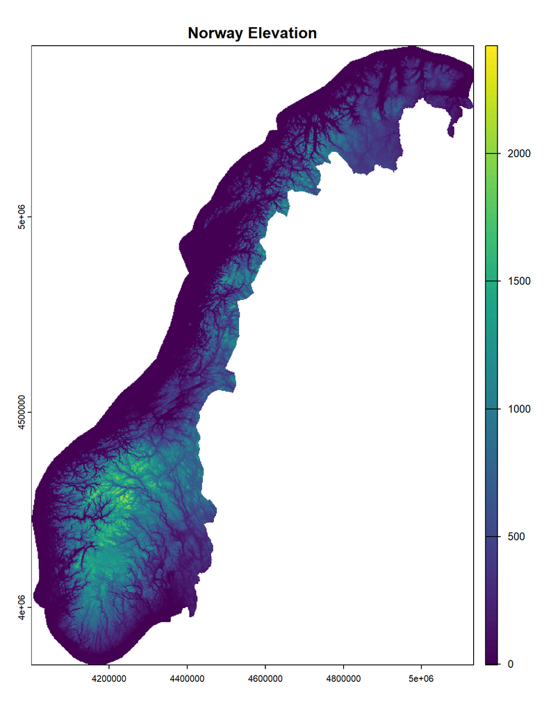

```r
# import data and plot
elev <- terra::rast(file.path(dfp,"version_2_2","inca_input_floodcontrol",
                              "DEM_and_Slope_maps",
                              "dt1_dem_INCA_EPSG3035_100m.tif"))
elev<-crop(elev,lcm)
elev<-mask(elev,lcm)
plot(elev,main="Norway Elevation")
```

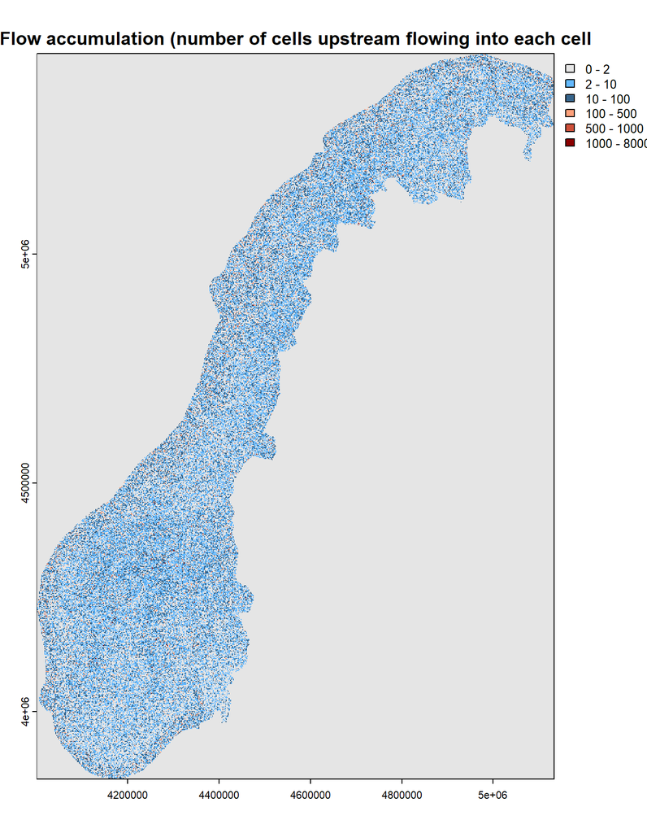

```r
# then the computation
set.seed(2025) # I do this for replicability. Flowdir allocates direction randomly when it is impossible to find a unique direction from the elevation data
flowdir_total <- terra::terrain(elev,v="flowdir")
# plot accumulation
flow_acc_total <- terra::flowAccumulation((flowdir_total))
plot(flow_acc_total, main = "Flow accumulation (number of cells upstream flowing into each cell",col=data.frame(from=c(0,2,10,100,500,1000),
                    to=c(2,10,100,500,1000,8000),
                    col=c("grey90","steelblue1","steelblue4","lightsalmon","tomato3","red4")))
```

```r
# clean up
rm(elev)
gc()
```

## 5.3 Ratio of Protection Upstream

### 5.3.1 Calculation and Results

Ok so now we tell terra to count upstream cells, but only those that are not SPAs. This gives us a hypothetical flow without water from SPA cells. So we basically simulate that SPA cells retain water. The way I implement this is to use the weight argument in the flowAccummulation function (I have tested the behaviour first on a hypothetical 9x9 grid).

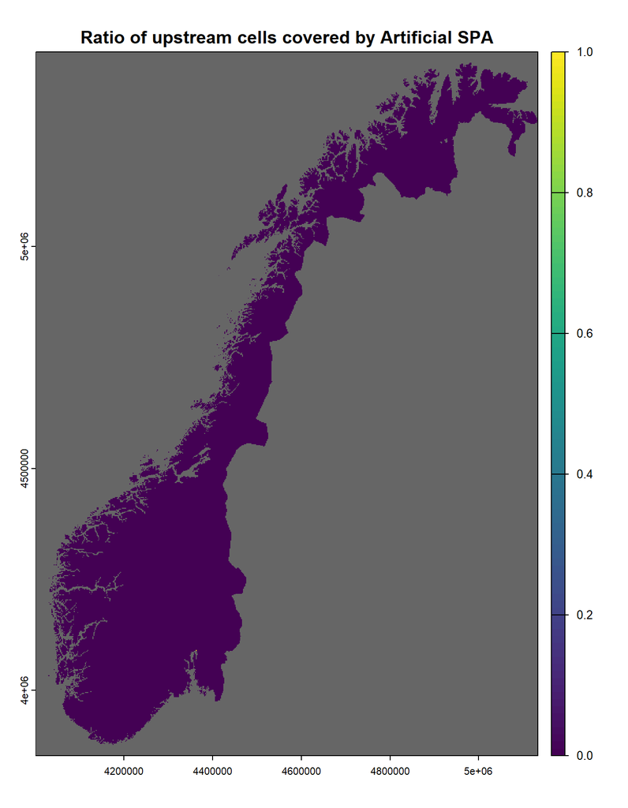

```r
## ratio artificial spa
tmp<-spam[[1]]
# invert 0 and 1
tmp<-tmp+1
tmp[tmp==2]<-0
# then compute restricted flow accummulation
flow_acc_tmp <- terra::flowAccumulation(flowdir_total,tmp)
# then calculate the ratio
ratio_artif<- 1 - flow_acc_tmp/flow_acc_total
# clean up
rm(tmp,flow_acc_tmp)
## ratio agricultural spa
tmp<-spam[[2]]
# invert 0 and 1
tmp<-tmp+1
tmp[tmp==2]<-0
# then compute restricted flow accummulation
flow_acc_tmp <- terra::flowAccumulation(flowdir_total,tmp)
# then calculate the ratio
ratio_agric<- 1 - flow_acc_tmp/flow_acc_total
# clean up
rm(tmp,flow_acc_tmp)
## ratio nature spa
tmp<-spam[[3]]
# invert 0 and 1
tmp<-tmp+1
tmp[tmp==2]<-0
# then compute restricted flow accummulation
flow_acc_tmp <- terra::flowAccumulation(flowdir_total,tmp)
# then calculate the ratio
ratio_natur<- 1 - flow_acc_tmp/flow_acc_total
# clean up
rm(tmp,flow_acc_tmp)
## plot results
plot(ratio_artif,colNA="grey40", main = "Ratio of upstream cells covered by Artificial SPA")
```

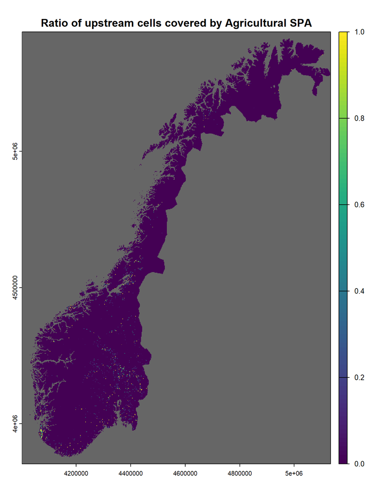

```r
plot(ratio_agric,colNA="grey40",main = "Ratio of upstream cells covered by Agricultural SPA")
```

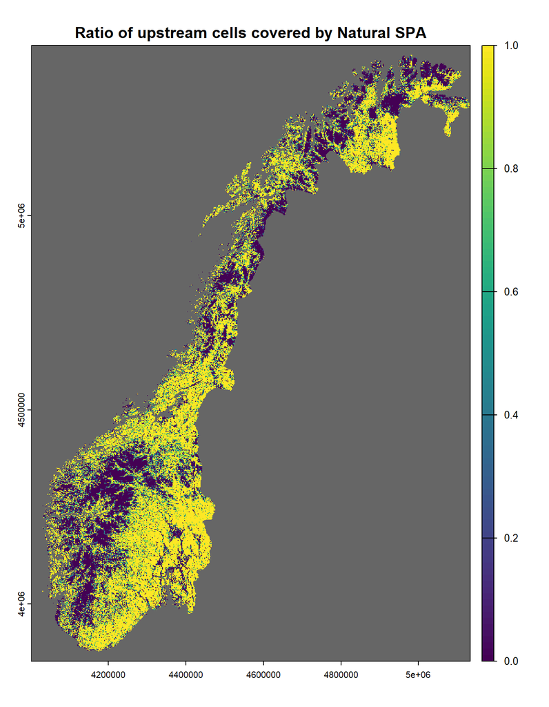

```r
plot(ratio_natur,colNA="grey40",main = "Ratio of upstream cells covered by Natural SPA")
```

```r
## save results as tif
writeRaster(ratio_agric,file.path(rfp,"ratio_agric.tif"),overwrite=T)
writeRaster(ratio_artif,file.path(rfp,"ratio_artif.tif"),overwrite=T)
writeRaster(ratio_natur,file.path(rfp,"ratio_natur.tif"),overwrite=T)
## clean up
rm(flow_acc_total,flowdir_total)
gc()
```

### 5.3.2 Plots for KS Project

Here the ratio plots for our KS cases. Only ratio of upstream cells covered by natural SPA.

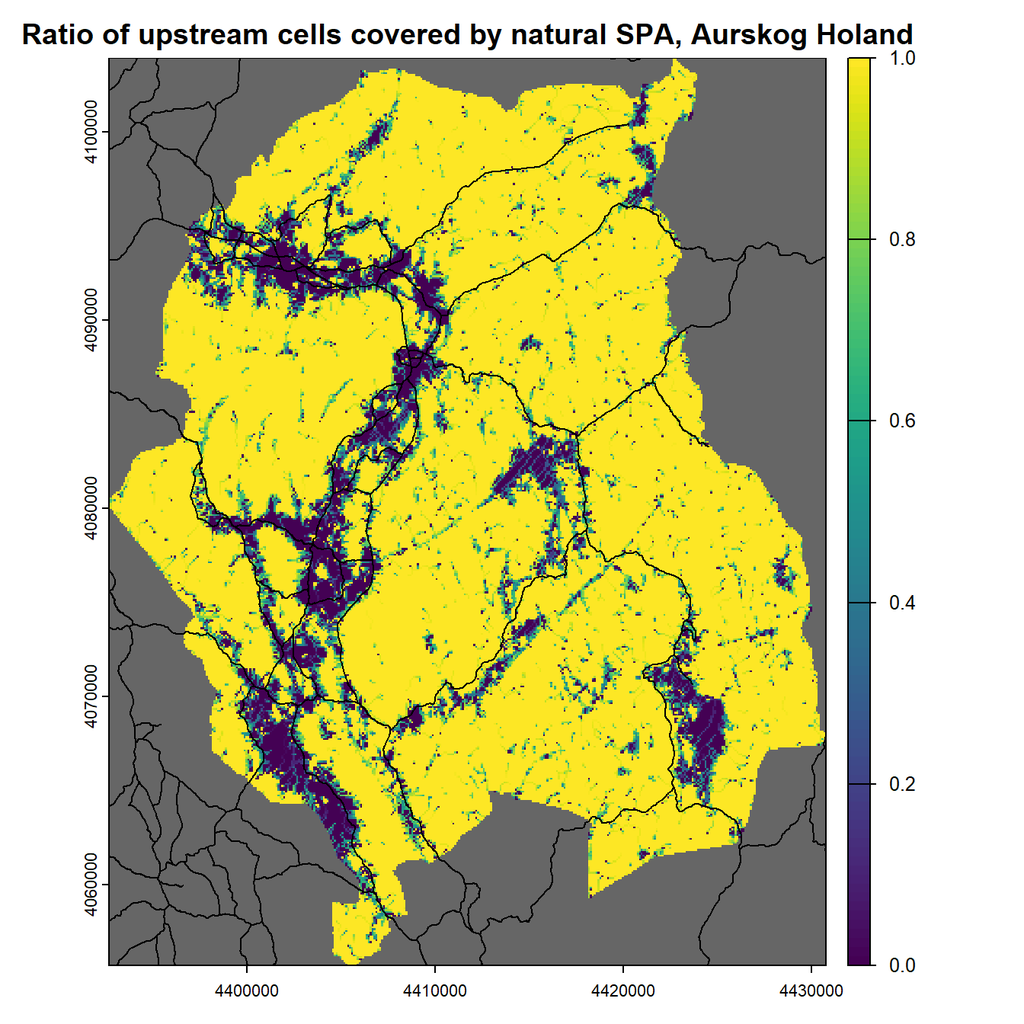

```r
# Aurskog Høland
plot(ratio_natur %>% crop(ahs,mask=T),colNA="grey40",
     main="Ratio of upstream cells covered by natural SPA, Aurskog Holand")
plot(ahr,add=T)
```

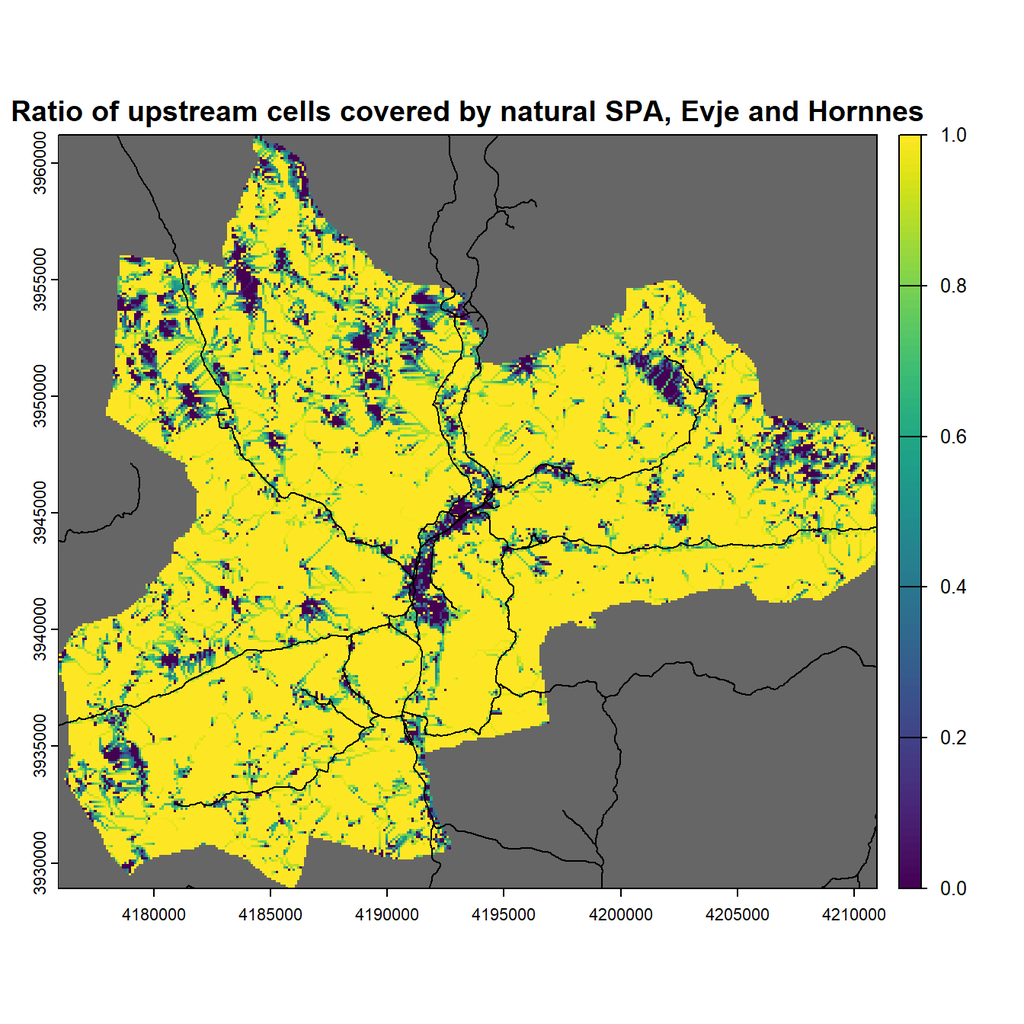

```r
# Evje and Hornnes
plot(ratio_natur %>% crop(ehs,mask=T),colNA="grey40",
     main="Ratio of upstream cells covered by natural SPA, Evje and Hornnes")
plot(ehr,add=T)
```

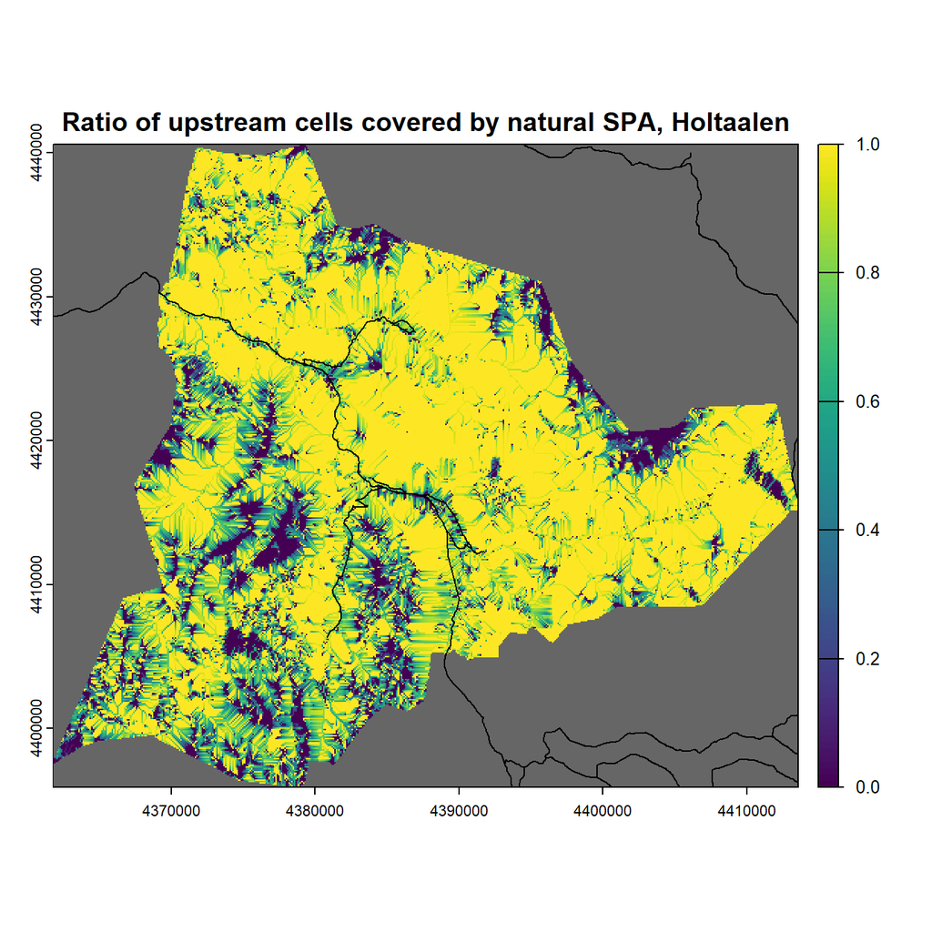

```r
# Holtålen
plot(ratio_natur %>% crop(hos,mask=T),colNA="grey40",
     main="Ratio of upstream cells covered by natural SPA, Holtaalen")
plot(hor,add=T)
```

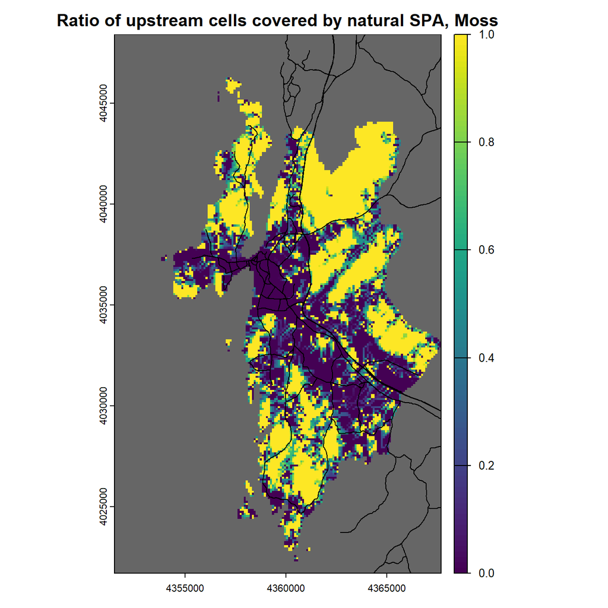

```r
#Moss
plot(ratio_natur %>% crop(mos,mask=T),colNA="grey40",
     main="Ratio of upstream cells covered by natural SPA, Moss")
plot(mor,add=T)
```

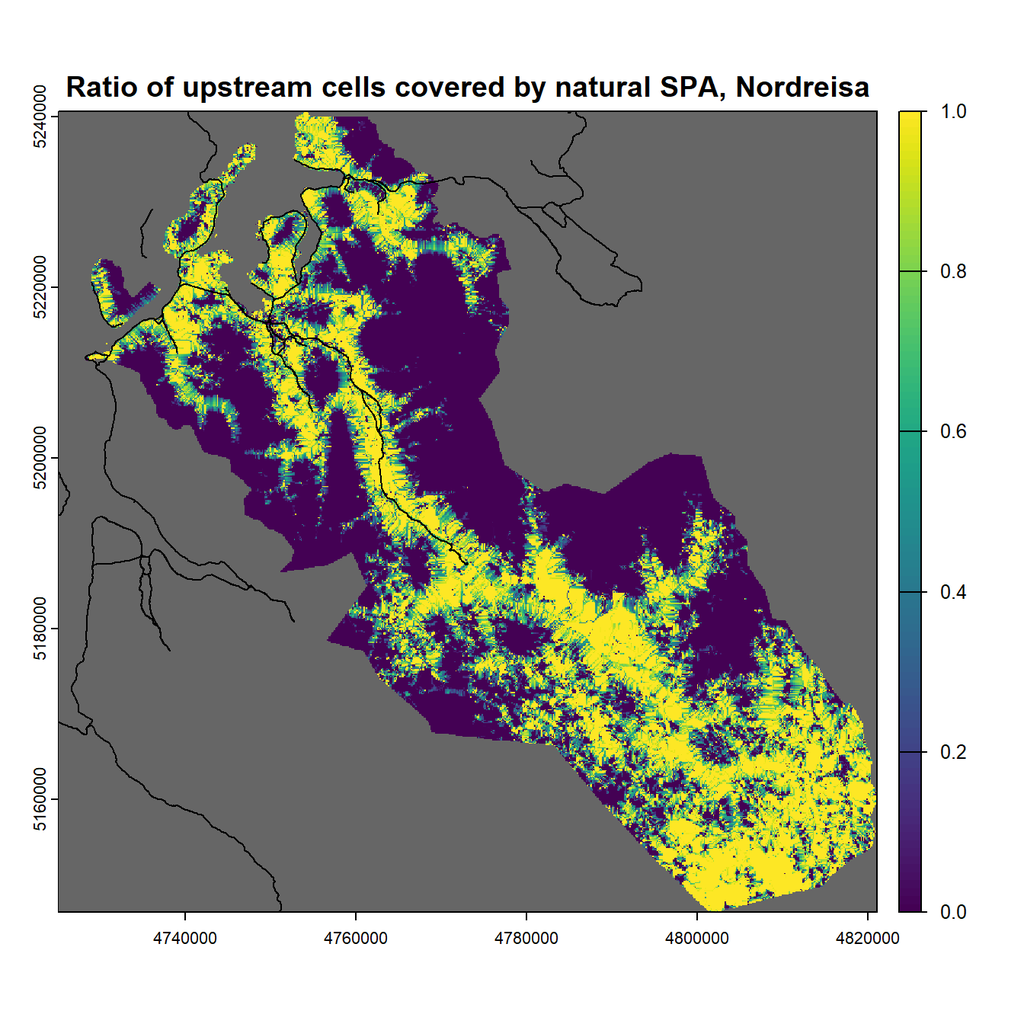

```r
# Nordreisa
plot(ratio_natur %>% crop(nrs,mask=T),colNA="grey40",
     main="Ratio of upstream cells covered by natural SPA, Nordreisa")
plot(nrr,add=T)
```

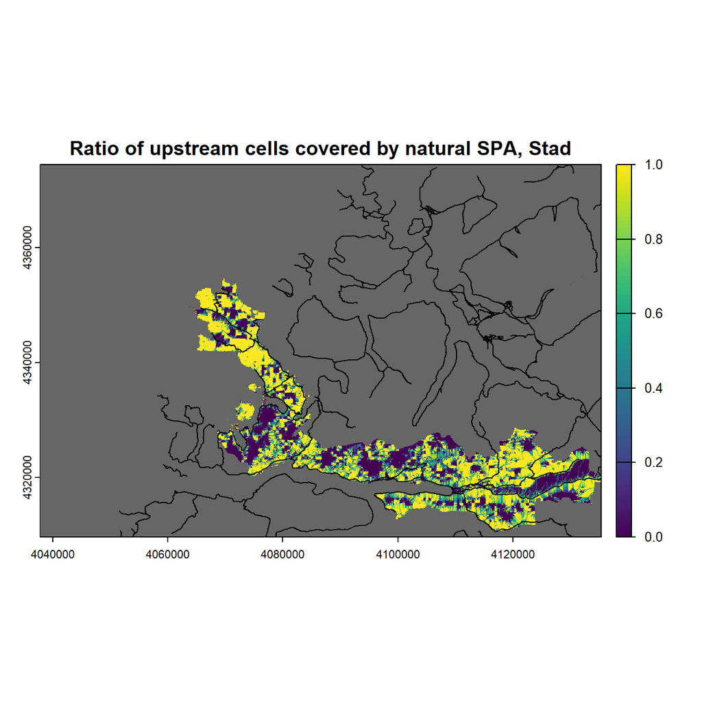

```r
# Stad
plot(ratio_natur %>% crop(sds,mask=T),colNA="grey40",
     main="Ratio of upstream cells covered by natural SPA, Stad")
plot(sdr,add=T)
```

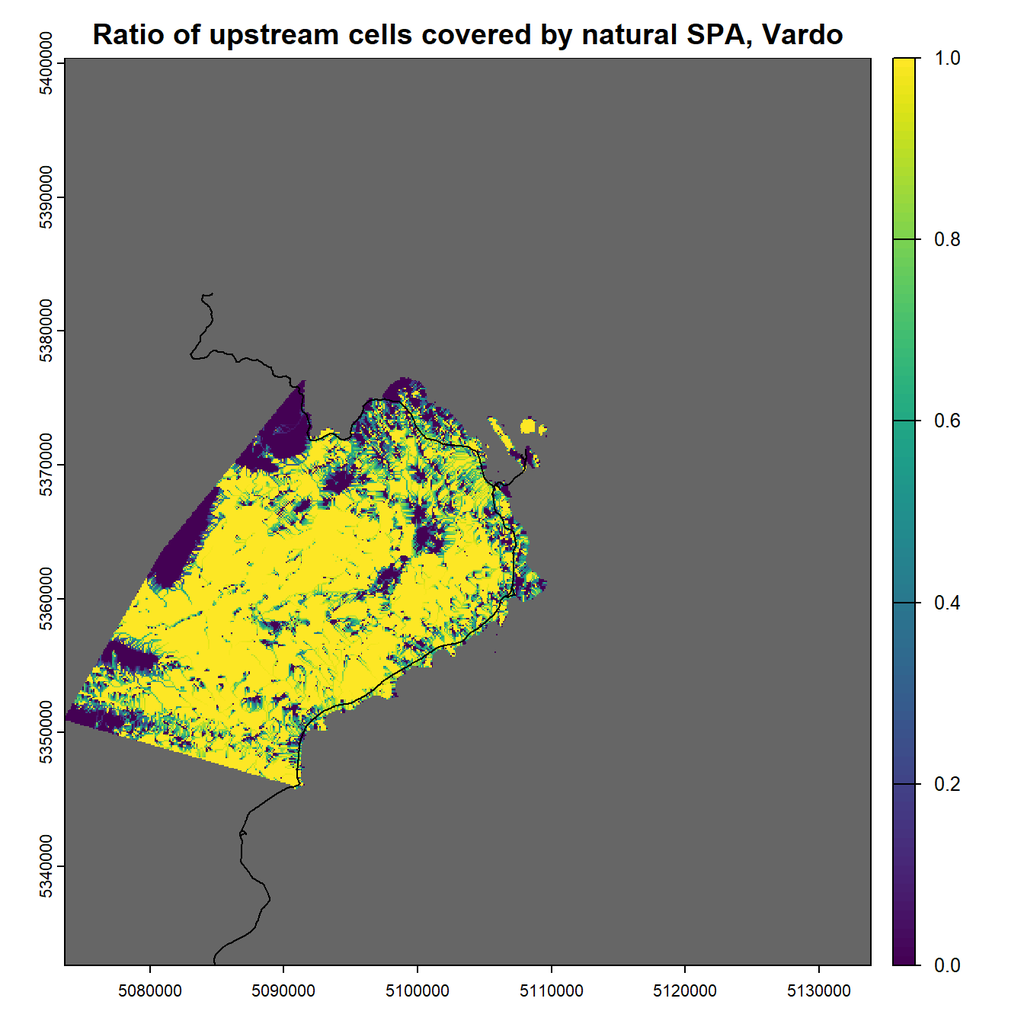

```r
# Vardø
plot(ratio_natur %>% crop(vrs,mask=T),colNA="grey40",
     main="Ratio of upstream cells covered by natural SPA, Vardo")
plot(vrr,add=T)
```

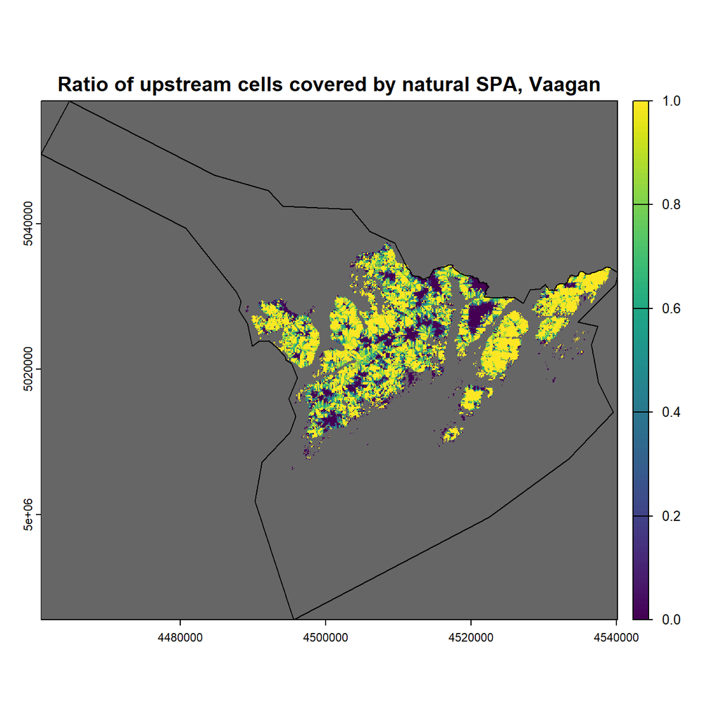

```r
# Vågan
plot(ratio_natur %>% crop(vas,mask=T),colNA="grey40",
     main="Ratio of upstream cells covered by natural SPA, Vaagan")
plot(vas,add=T)
```

```r
# clean up
gc()
```

## 5.4 Service Flow

### 5.4.1 Calculation and Results

Now we have the ratios, so next we can compute for each service demanding area what the respective service flow is. We can make maps of it and also tables.

```r
## serice flow to meet demand by artificial area
flow_d_artif_s_artif<-sdam_artif*ratio_artif
flow_d_artif_s_agric<-sdam_artif*ratio_agric
flow_d_artif_s_natur<-sdam_artif*ratio_natur
## serice flow to meet demand by agricultural area
flow_d_agric_s_artif<-sdam_agric*ratio_artif
flow_d_agric_s_agric<-sdam_agric*ratio_agric
flow_d_agric_s_natur<-sdam_agric*ratio_natur
## serice flow to meet demand by population
flow_d_pop_s_artif<-sdam_pop*ratio_artif
flow_d_pop_s_agric<-sdam_pop*ratio_agric
flow_d_pop_s_natur<-sdam_pop*ratio_natur
## here add the aggregate ones econ and pop, and save those two as rasters.
flow_d_econ <- flow_d_artif_s_artif + flow_d_artif_s_agric + flow_d_artif_s_natur +
  flow_d_agric_s_artif + flow_d_agric_s_agric + flow_d_agric_s_natur
flow_d_pop <- flow_d_pop_s_artif + flow_d_pop_s_agric + flow_d_pop_s_natur
# total flows
flow_d_all_s_all<-flow_d_artif_s_artif+flow_d_artif_s_agric+flow_d_artif_s_natur+
  flow_d_agric_s_artif+flow_d_agric_s_agric+flow_d_agric_s_natur
## save results as tif
rfp<-file.path("C:","Users","muk",
               paste0("OneDrive - Statistisk sentralbyr","\U00E5"),
               "Projects","Naturregnskap","Flomkontroll","Norway_R","output_maps")
writeRaster(flow_d_econ,file.path(rfp,"flow_d_econ.tif"),overwrite=T)
writeRaster(flow_d_pop,file.path(rfp,"flow_d_pop.tif"),overwrite=T)
# Make a table of values
flow_df<-as.data.frame(matrix(ncol=4,nrow=3))
colnames(flow_df)<-c("provision_cat","demand_artif","demand_agric","demand_pop")
flow_df$provision_cat<-c("artif","agric","natur")
# for demand artif
flow_df$demand_artif[flow_df$provision_cat=="artif"]<-sum(values(flow_d_artif_s_artif),na.rm=T)
flow_df$demand_artif[flow_df$provision_cat=="agric"]<-sum(values(flow_d_artif_s_agric),na.rm=T)
flow_df$demand_artif[flow_df$provision_cat=="natur"]<-sum(values(flow_d_artif_s_natur),na.rm=T)
# for demand agric
flow_df$demand_agric[flow_df$provision_cat=="artif"]<-sum(values(flow_d_agric_s_artif),na.rm=T)
flow_df$demand_agric[flow_df$provision_cat=="agric"]<-sum(values(flow_d_agric_s_agric),na.rm=T)
flow_df$demand_agric[flow_df$provision_cat=="natur"]<-sum(values(flow_d_agric_s_natur),na.rm=T)
# for demand pop
flow_df$demand_pop[flow_df$provision_cat=="artif"]<-sum(values(flow_d_pop_s_artif),na.rm=T)
flow_df$demand_pop[flow_df$provision_cat=="agric"]<-sum(values(flow_d_pop_s_agric),na.rm=T)
flow_df$demand_pop[flow_df$provision_cat=="natur"]<-sum(values(flow_d_pop_s_natur),na.rm=T)
#clean up
rm(flow_d_artif_s_artif,flow_d_artif_s_agric,flow_d_artif_s_natur,flow_d_agric_s_artif,flow_d_agric_s_agric,flow_d_agric_s_natur,flow_d_pop_s_artif,flow_d_pop_s_agric,flow_d_pop_s_natur,ratio_agric,ratio_artif,ratio_natur)
gc()
```

Here is the table

```r
# print table
kable(flow_df)
```

| provision_cat | demand_artif | demand_agric | demand_pop |
| --- | --- | --- | --- |
| artif | 363.6938 | 32.97053 | 2127.256 |
| agric | 1914.0109 | 35630.01987 | 10133.817 |
| natur | 43235.0611 | 84679.96340 | 159911.109 |

### 5.4.2 Plots for KS Project

Let’s take a look at the flows for our municipalities of interest in the KS project. Only total flow (from all SPAs) to economic assets and to population. Service demanding areas are shaded lighter, so we can compare service flows to demanded service.

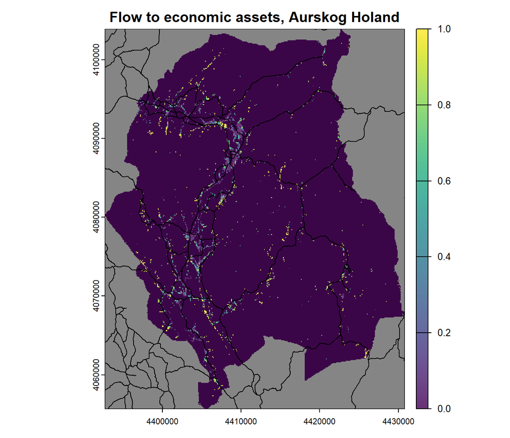

```r
# Aurskog Høland
#econ
plot(sdam_econ %>% crop(ahs,mask=T),colNA="white",
     col=data.frame(value=c(1,0),col=c("white","grey10")),legend=F,
     main="Flow to economic assets, Aurskog Holand")
plot(flow_d_econ %>% crop(ahs,mask=T),colNA="grey40",add=T,alpha=0.8)
plot(ahr,add=T)
```

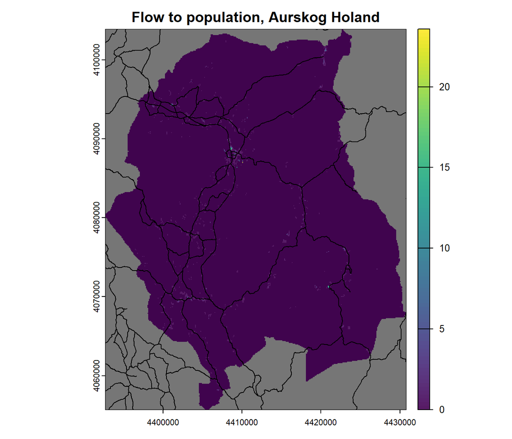

```r
#pop
plot(sdam_pop %>% crop(ahs,mask=T),colNA="white",
     col=data.frame(from=c(0,0.00001),to=c(0,Inf),col=c("grey10","white")),legend=F,
     main="Flow to population, Aurskog Holand")
plot(flow_d_pop %>% crop(ahs,mask=T),colNA="grey40",add=T,alpha=0.9)
plot(ahr,add=T)
```

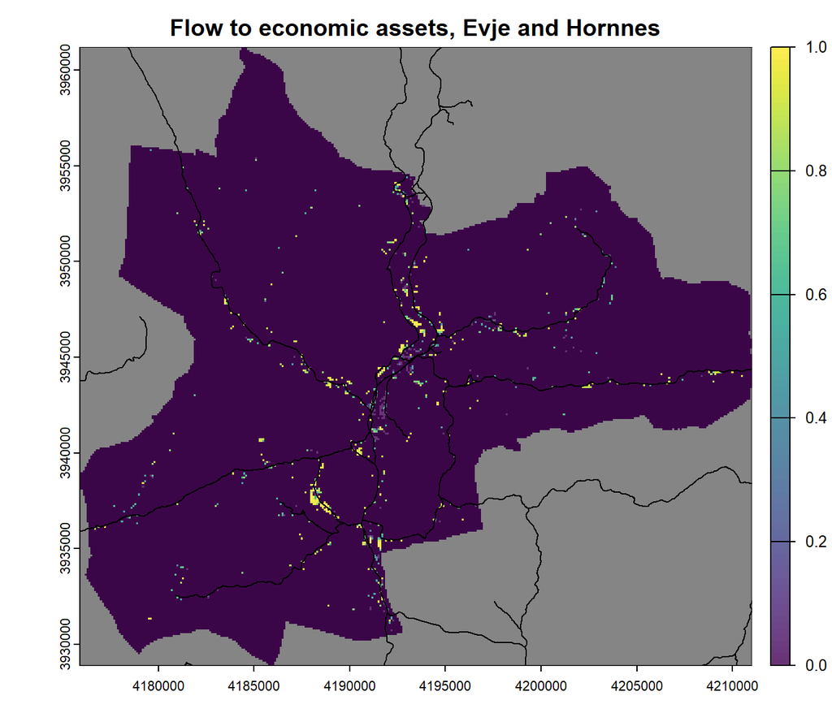

```r
# Evje and Hornnes
#econ
plot(sdam_econ %>% crop(ehs,mask=T),colNA="white",
     col=data.frame(value=c(1,0),col=c("white","grey10")),legend=F,
     main="Flow to economic assets, Evje and Hornnes")
plot(flow_d_econ %>% crop(ehs,mask=T),colNA="grey40",add=T,alpha=0.8)
plot(ehr,add=T)
```

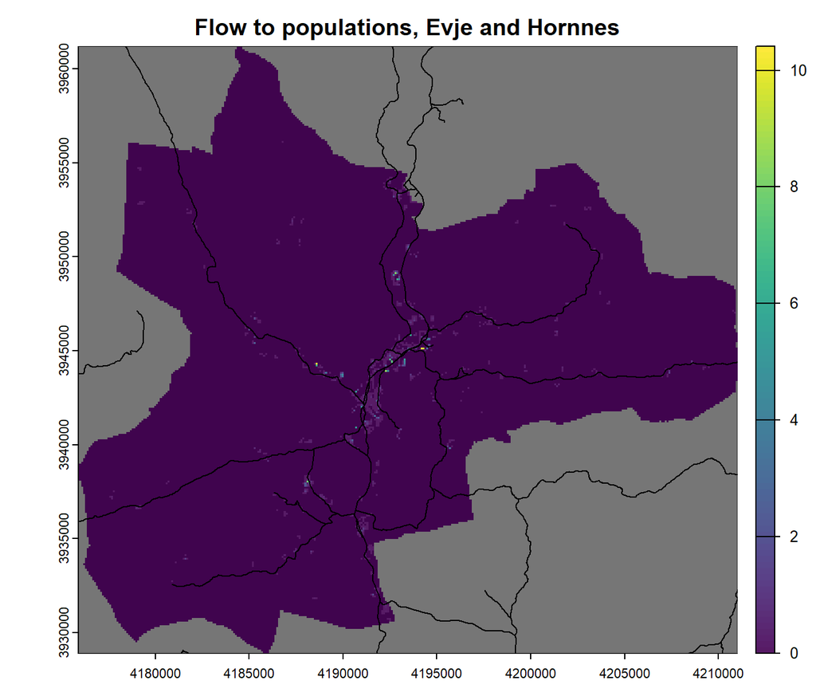

```r
#pop
plot(sdam_pop %>% crop(ehs,mask=T),colNA="white",
     col=data.frame(from=c(0,0.00001),to=c(0,Inf),col=c("grey10","white")),legend=F,
     main="Flow to populations, Evje and Hornnes")
plot(flow_d_pop %>% crop(ehs,mask=T),colNA="grey40",add=T,alpha=0.9)
plot(ehr,add=T)
```

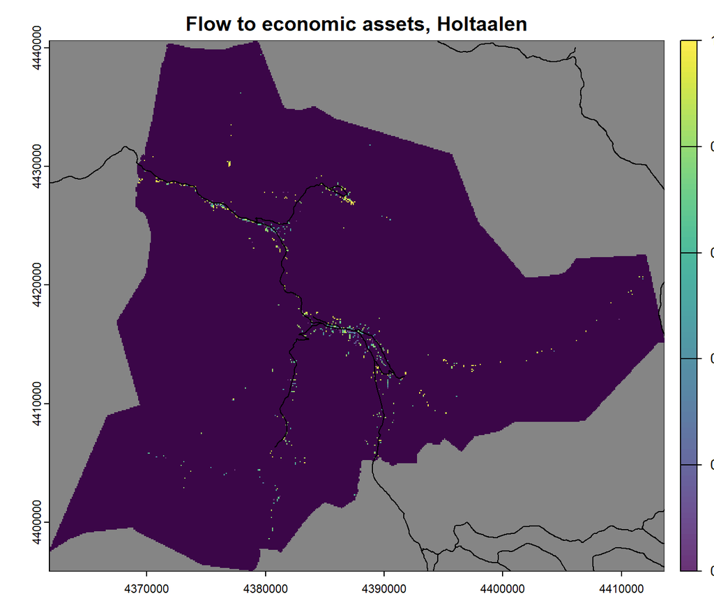

```r
# Holtålen
#econ
plot(sdam_econ %>% crop(hos,mask=T),colNA="white",
     col=data.frame(value=c(1,0),col=c("white","grey10")),legend=F,
     main="Flow to economic assets, Holtaalen")
plot(flow_d_econ %>% crop(hos,mask=T),colNA="grey40",add=T,alpha=0.8)
plot(hor,add=T)
```

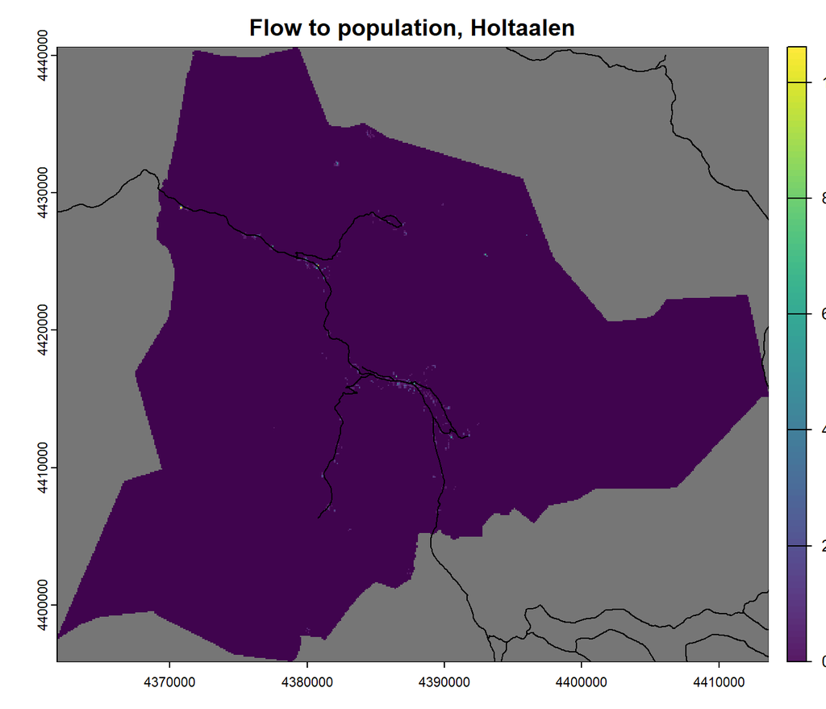

```r
#pop
plot(sdam_pop %>% crop(hos,mask=T),colNA="white",
     col=data.frame(from=c(0,0.00001),to=c(0,Inf),col=c("grey10","white")),legend=F,
     main="Flow to population, Holtaalen")
plot(flow_d_pop %>% crop(hos,mask=T),colNA="grey40",add=T,alpha=0.9)
plot(hor,add=T)
```

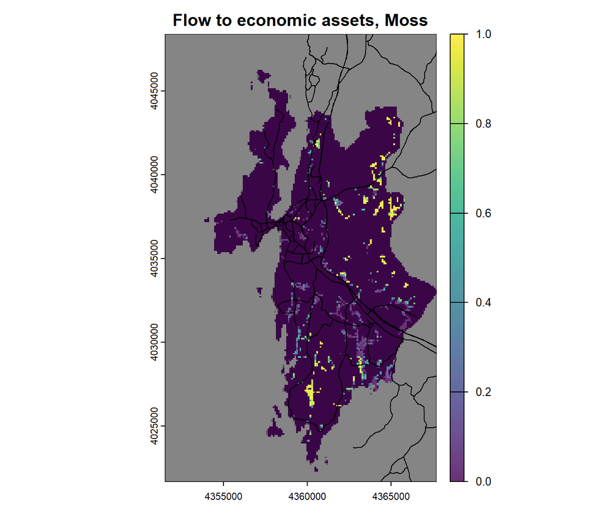

```r
#Moss
#econ
plot(sdam_econ %>% crop(mos,mask=T),colNA="white",
     col=data.frame(value=c(1,0),col=c("white","grey10")),legend=F,
     main="Flow to economic assets, Moss")
plot(flow_d_econ %>% crop(mos,mask=T),colNA="grey40",add=T,alpha=0.8)
plot(mor,add=T)
```

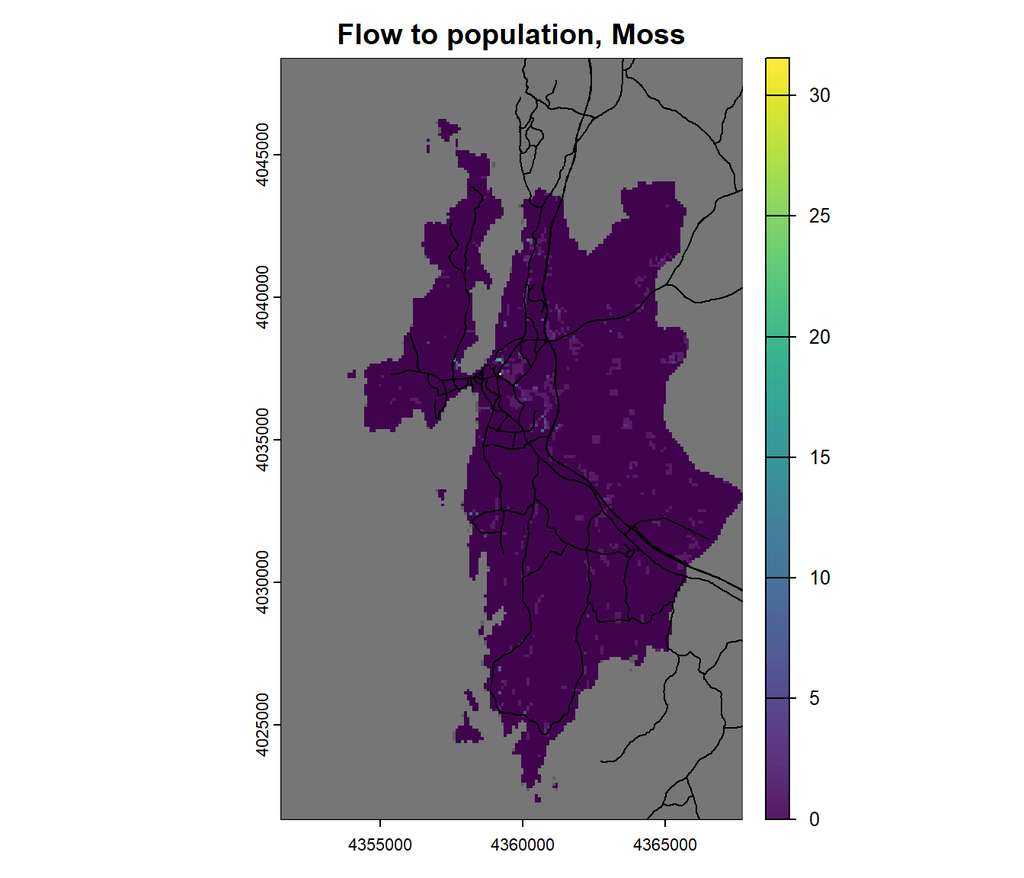

```r
#pop
plot(sdam_pop %>% crop(mos,mask=T),colNA="white",
     col=data.frame(from=c(0,0.00001),to=c(0,Inf),col=c("grey10","white")),legend=F,
     main="Flow to population, Moss")
plot(flow_d_pop %>% crop(mos,mask=T),colNA="grey40",add=T,alpha=0.9)
plot(mor,add=T)
```

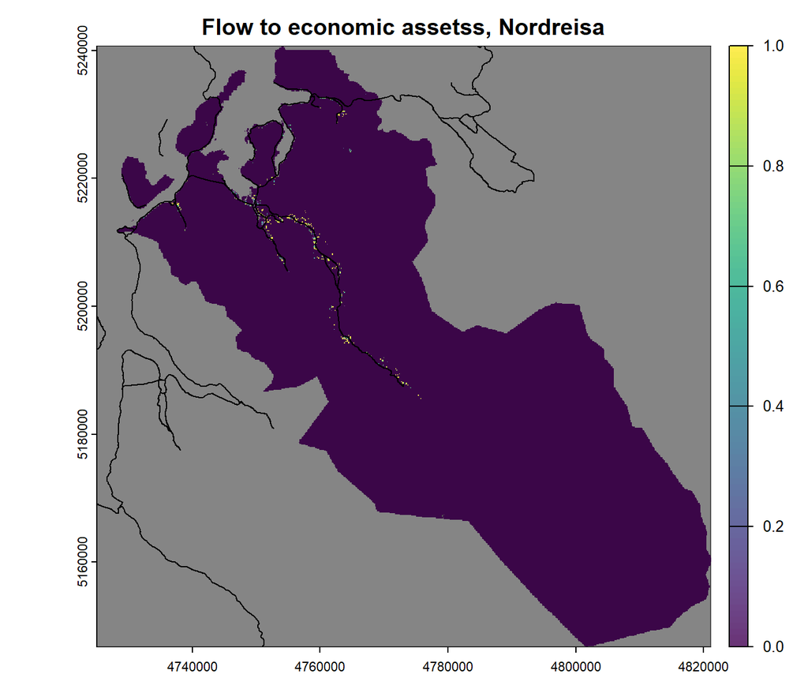

```r
# Nordreisa
#econ
plot(sdam_econ %>% crop(nrs,mask=T),colNA="white",
     col=data.frame(value=c(1,0),col=c("white","grey10")),legend=F,
     main="Flow to economic assetss, Nordreisa")
plot(flow_d_econ %>% crop(nrs,mask=T),colNA="grey40",add=T,alpha=0.8)
plot(nrr,add=T)
```

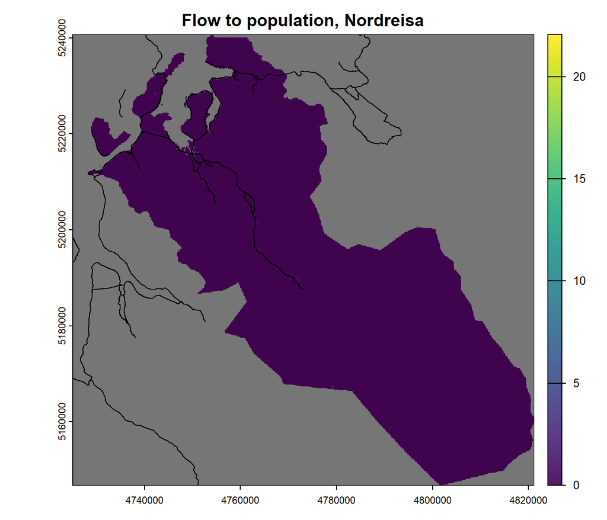

```r
#pop
plot(sdam_pop %>% crop(nrs,mask=T),colNA="white",
     col=data.frame(from=c(0,0.00001),to=c(0,Inf),col=c("grey10","white")),legend=F,
     main="Flow to population, Nordreisa")
plot(flow_d_pop %>% crop(nrs,mask=T),colNA="grey40",add=T,alpha=0.9)
plot(nrr,add=T)
```

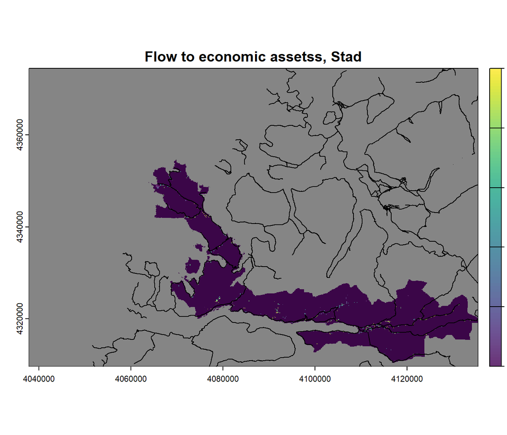

```r
# Stad
#econ
plot(sdam_econ %>% crop(sds,mask=T),colNA="white",
     col=data.frame(value=c(1,0),col=c("white","grey10")),legend=F,
     main="Flow to economic assetss, Stad")
plot(flow_d_econ %>% crop(sds,mask=T),colNA="grey40",add=T,alpha=0.8)
plot(sdr,add=T)
```

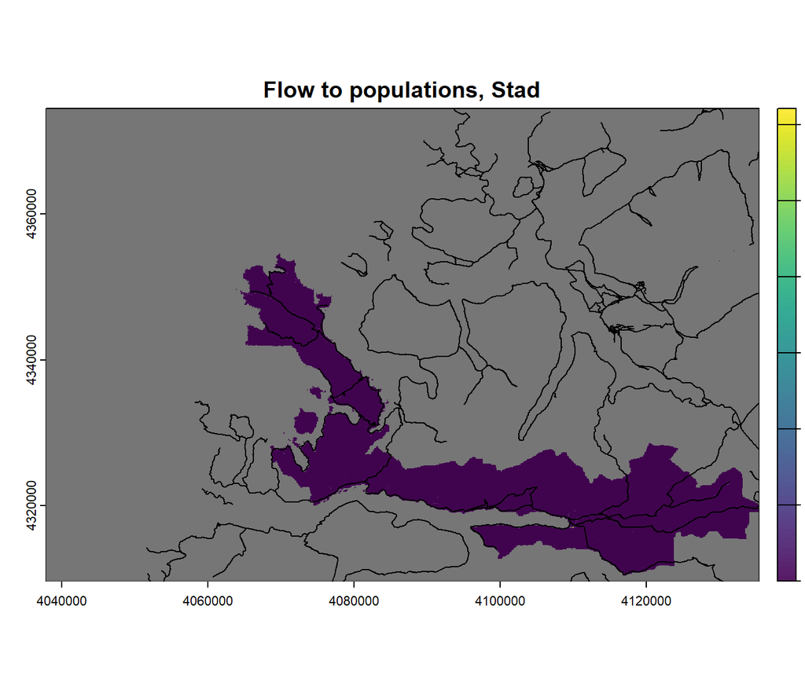

```r
#pop
plot(sdam_pop %>% crop(sds,mask=T),colNA="white",
     col=data.frame(from=c(0,0.00001),to=c(0,Inf),col=c("grey10","white")),legend=F,
     main="Flow to populations, Stad")
plot(flow_d_pop %>% crop(sds,mask=T),colNA="grey40",add=T,alpha=0.9)
plot(sdr,add=T)
```

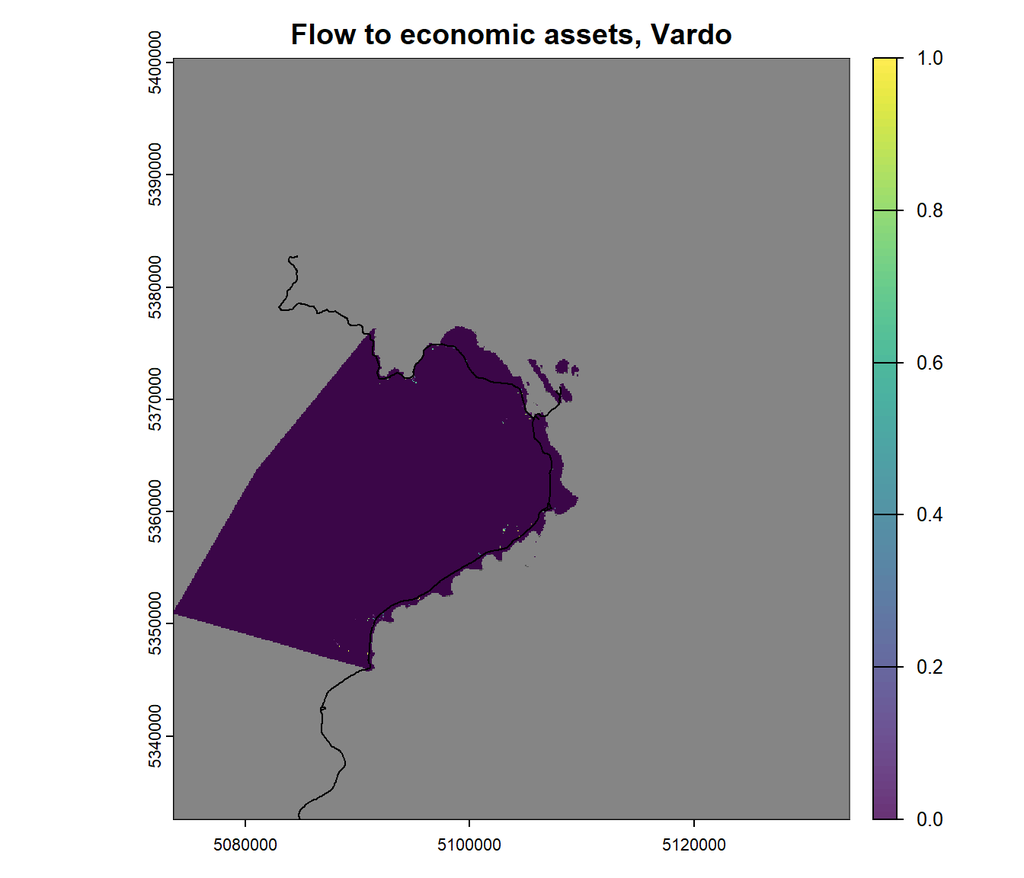

```r
# Vardø
#econ
plot(sdam_econ %>% crop(vrs,mask=T),colNA="white",
     col=data.frame(value=c(1,0),col=c("white","grey10")),legend=F,
     main="Flow to economic assets, Vardo")
plot(flow_d_econ %>% crop(vrs,mask=T),colNA="grey40",add=T,alpha=0.8)
plot(vrr,add=T)
```

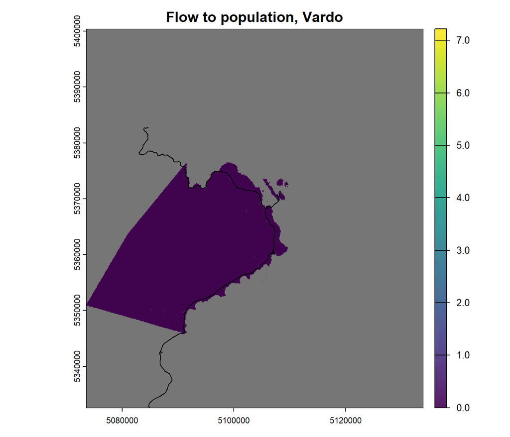

```r
#pop
plot(sdam_pop %>% crop(vrs,mask=T),colNA="white",
     col=data.frame(from=c(0,0.00001),to=c(0,Inf),col=c("grey10","white")),legend=F,
     main="Flow to population, Vardo")
plot(flow_d_pop %>% crop(vrs,mask=T),colNA="grey40",add=T,alpha=0.9)
plot(vrr,add=T)
```

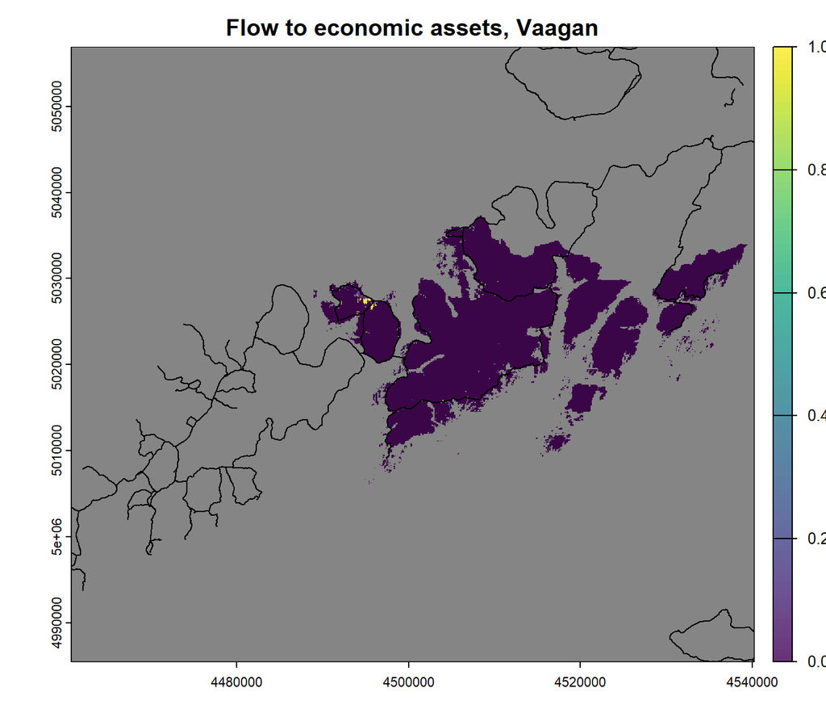

```r
# Vågan
#econ
plot(sdam_econ %>% crop(vas,mask=T),colNA="white",
     col=data.frame(value=c(1,0),col=c("white","grey10")),legend=F,
     main="Flow to economic assets, Vaagan")
plot(flow_d_econ %>% crop(vas,mask=T),colNA="grey40",add=T,alpha=0.8)
plot(var,add=T)
```

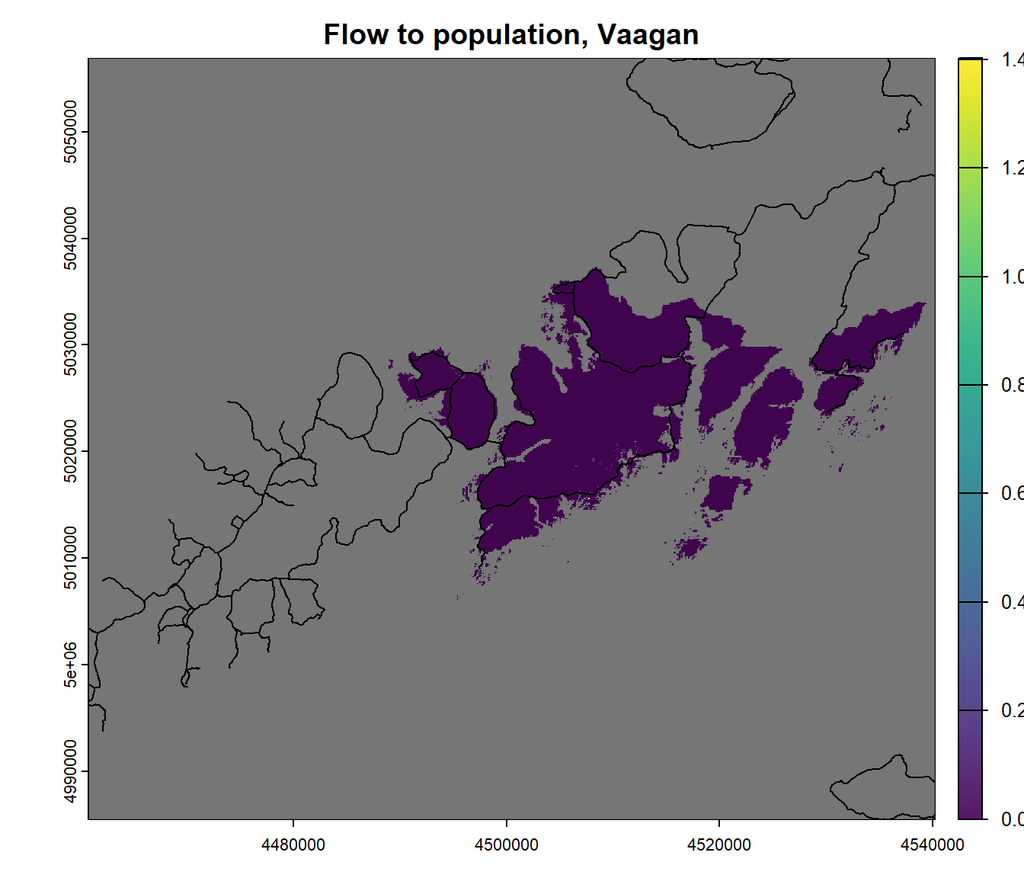

```r
#pop
plot(sdam_pop %>% crop(vas,mask=T),colNA="white",
     col=data.frame(from=c(0,0.00001),to=c(0,Inf),col=c("grey10","white")),legend=F,
     main="Flow to population, Vaagan")
plot(flow_d_pop %>% crop(vas,mask=T),colNA="grey40",add=T,alpha=0.9)
plot(var,add=T)
```

```r
# clean up
gc()
```

# 6. Met and Unmet Demand

## 6.1 Table

Unmet demand is equal to total demand minus provided service. We can express both as absolute and relative numbers. I first make a table for this.

```r
# I make a table of all
dem_df<-as.data.frame(matrix(ncol = 4,nrow=7))
colnames(dem_df)<-c("indicator","demand_artif","demand_agric","demand_pop")
dem_df$indicator<-c("total_demand","total_provided","unmet_demand","rel_prov_artif","rel_prov_agric","rel_prov_natur","rel_unmet")
# total demand
dem_df$demand_artif[dem_df$indicator=="total_demand"]<-sum(values(sdam_artif),na.rm=T)
dem_df$demand_agric[dem_df$indicator=="total_demand"]<-sum(values(sdam_agric),na.rm=T)
dem_df$demand_pop[dem_df$indicator=="total_demand"]<-sum(values(sdam_pop),na.rm=T)
# total provided
dem_df$demand_artif[dem_df$indicator=="total_provided"]<-sum(flow_df$demand_artif)
dem_df$demand_agric[dem_df$indicator=="total_provided"]<-sum(flow_df$demand_agric)
dem_df$demand_pop[dem_df$indicator=="total_provided"]<-sum(flow_df$demand_pop)
# unmet
dem_df$demand_artif[dem_df$indicator=="unmet_demand"]<-dem_df$demand_artif[dem_df$indicator=="total_demand"] - dem_df$demand_artif[dem_df$indicator=="total_provided"]
dem_df$demand_agric[dem_df$indicator=="unmet_demand"]<-dem_df$demand_agric[dem_df$indicator=="total_demand"] - dem_df$demand_agric[dem_df$indicator=="total_provided"]
dem_df$demand_pop[dem_df$indicator=="unmet_demand"]<-dem_df$demand_pop[dem_df$indicator=="total_demand"] - dem_df$demand_pop[dem_df$indicator=="total_provided"]
# relative provision by artificial cells
dem_df$demand_artif[dem_df$indicator=="rel_prov_artif"]<-round(flow_df$demand_artif[flow_df$provision_cat=="artif"]/dem_df$demand_artif[dem_df$indicator=="total_demand"],digits=3)
dem_df$demand_agric[dem_df$indicator=="rel_prov_artif"]<-round(flow_df$demand_agric[flow_df$provision_cat=="artif"]/dem_df$demand_agric[dem_df$indicator=="total_demand"],digits=3)
dem_df$demand_pop[dem_df$indicator=="rel_prov_artif"]<-round(flow_df$demand_pop[flow_df$provision_cat=="artif"]/dem_df$demand_pop[dem_df$indicator=="total_demand"],digits=3)
# relative provision by agricultural cells
dem_df$demand_artif[dem_df$indicator=="rel_prov_agric"]<-round(flow_df$demand_artif[flow_df$provision_cat=="agric"]/dem_df$demand_artif[dem_df$indicator=="total_demand"],digits=3)
dem_df$demand_agric[dem_df$indicator=="rel_prov_agric"]<-round(flow_df$demand_agric[flow_df$provision_cat=="agric"]/dem_df$demand_agric[dem_df$indicator=="total_demand"],digits=3)
dem_df$demand_pop[dem_df$indicator=="rel_prov_agric"]<-round(flow_df$demand_pop[flow_df$provision_cat=="agric"]/dem_df$demand_pop[dem_df$indicator=="total_demand"],digits=3)
# relative provision by natural cells
dem_df$demand_artif[dem_df$indicator=="rel_prov_natur"]<-round(flow_df$demand_artif[flow_df$provision_cat=="natur"]/dem_df$demand_artif[dem_df$indicator=="total_demand"],digits=3)
dem_df$demand_agric[dem_df$indicator=="rel_prov_natur"]<-round(flow_df$demand_agric[flow_df$provision_cat=="natur"]/dem_df$demand_agric[dem_df$indicator=="total_demand"],digits=3)
dem_df$demand_pop[dem_df$indicator=="rel_prov_natur"]<-round(flow_df$demand_pop[flow_df$provision_cat=="natur"]/dem_df$demand_pop[dem_df$indicator=="total_demand"],digits=3)
# relative unmet demand
dem_df$demand_artif[dem_df$indicator=="rel_unmet"]<-round(dem_df$demand_artif[dem_df$indicator=="unmet_demand"]/dem_df$demand_artif[dem_df$indicator=="total_demand"],digits=3)
dem_df$demand_agric[dem_df$indicator=="rel_unmet"]<-round(dem_df$demand_agric[dem_df$indicator=="unmet_demand"]/dem_df$demand_agric[dem_df$indicator=="total_demand"],digits=3)
dem_df$demand_pop[dem_df$indicator=="rel_unmet"]<-round(dem_df$demand_pop[dem_df$indicator=="unmet_demand"]/dem_df$demand_pop[dem_df$indicator=="total_demand"],digits=3)
# clean up
rm(sdam_agric,sdam_artif)
gc()
```

Here is the table

```r
# print table
kable(dem_df)
```

| indicator | demand_artif | demand_agric | demand_pop |
| --- | --- | --- | --- |
| total_demand | 101663.000 | 214931.000 | 702020.160 |
| total_provided | 45512.766 | 120342.954 | 172172.183 |
| unmet_demand | 56150.234 | 94588.046 | 529847.977 |
| rel_prov_artif | 0.004 | 0.000 | 0.003 |
| rel_prov_agric | 0.019 | 0.166 | 0.014 |
| rel_prov_natur | 0.425 | 0.394 | 0.228 |
| rel_unmet | 0.552 | 0.440 | 0.755 |

Relevant to note here is that we use population number in case of demand category “pop” and we use cells in case of demand categories “artif” and “agric”. We may want to switch all to the count of cells. Then the respective result just has to be multiplied by the spatial size of each cell (each cell one hectare).

## 6.2 Plots by Catchment Area

```r
# import shape
catch<-terra::vect(file.path(dfp,"Norway_files","NVE_vassdragomr","NVEKartdata",
                             "NVEData","Nedborfelt",
                             "Nedborfelt_Vassdragsomr.shp"))
```

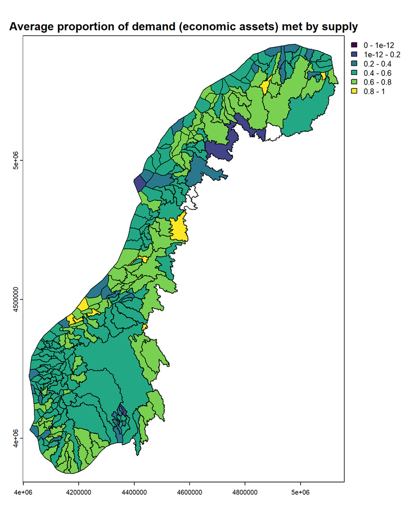

```r
# reproject
catch <- terra::project(catch,crs(lcm))
# remove svalbard
catch <- crop(catch,ext(4020798.64910517, 5135860.76845464, 3873563.87082421, 5500000))
# use terra::extract. This sums across cells within each polygon. A cell is
# within a polygon if its center is within the polygon.
# first we need a version where NA values are zeros, otherwise it returns NA everywhere
flow_d_econ_adj<-flow_d_econ
flow_d_econ_adj[is.na(flow_d_econ_adj)]<-0
sdam_econ_adj<-sdam_econ
sdam_econ_adj[is.na(sdam_econ_adj)]<-0
metr_d_econ <- flow_d_econ_adj/sdam_econ_adj
# get averages by area
metr_d_econ_by_catch <- terra::zonal(metr_d_econ,catch,fun = "mean",na.rm=T,touches=F)
# add data to the shapefile. We can do this because terra::zonal returns values in the same order as the attribute table of the spatial vector file
catch$metdecon <- metr_d_econ_by_catch[,1]
# plot
plot(catch,"metdecon",breaks=c(0,0.000000000001,0.2, 0.4, 0.6, 0.8, 1),col=viridis(6),main="Average proportion of demand (economic assets) met by supply")
```

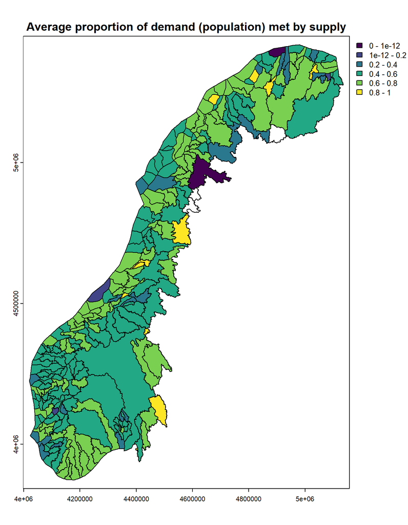

```r
## then the same for demand by population
flow_d_pop_adj<-flow_d_pop
flow_d_pop_adj[is.na(flow_d_pop_adj)]<-0
sdam_pop_adj<-sdam_pop
sdam_pop_adj[is.na(sdam_pop_adj)]<-0
metr_d_pop <- flow_d_pop_adj/sdam_pop_adj
# average by area
metr_d_pop_by_catch <- terra::zonal(metr_d_pop,catch,fun = "mean",na.rm=T,touches=F)
# add data to the shapefile. We can do this because terra::zonal returns values in the same order as the attribute table of the spatial vector file
catch$metdpop <- metr_d_pop_by_catch[,1]
# plot
plot(catch,"metdpop",breaks=c(0,0.000000000001,0.2, 0.4, 0.6, 0.8, 1),col=viridis(6), main="Average proportion of demand (population) met by supply")
```

```r
# clean up
rm(catch,flow_d_econ_adj,sdam_econ_adj,flow_d_pop_adj,sdam_pop_adj,metr_d_econ_by_catch,metr_d_pop_by_catch,metr_d_econ,metr_d_pop)
gc()
```

# 7. Supply and Use Tables (SUT)

## 7.1 SUT Norway and NUTS2

First we make a land cover map showing the supply categories we want to report in. And we need to aggregate our flows.

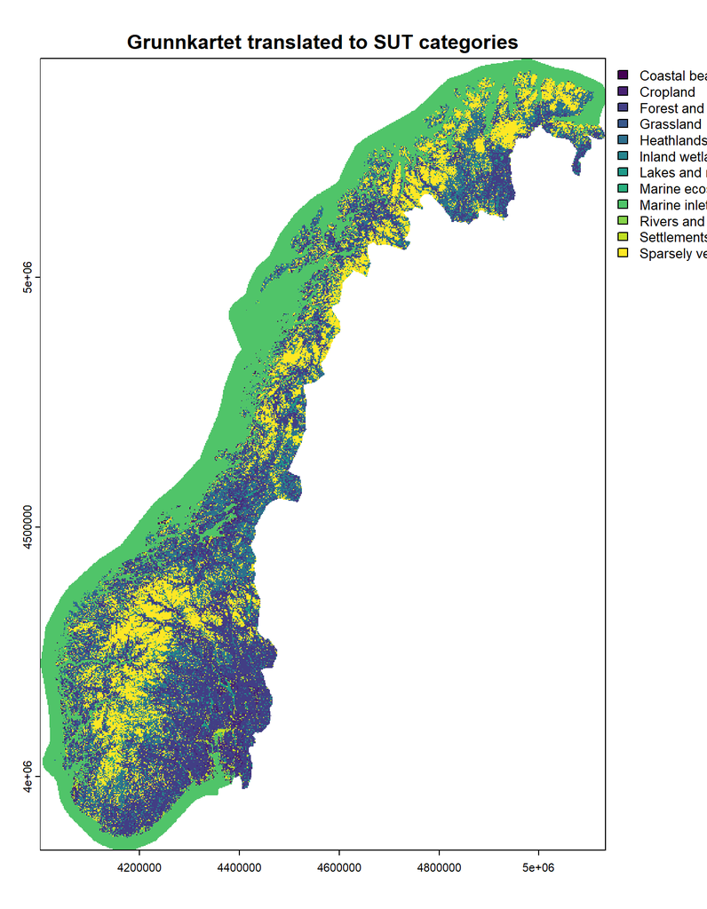

```r
# so first make the vector of ecosystem types
estv<-c("Settlements and other artificial areas",
        "Cropland",
        "Grassland",
        "Forest and woodlands",
        "Heathlands and shrub",
        "Sparsely vegetated ecosystems",
        "Inland wetlands",
        "Rivers and canals",
        "Lakes and reservoirs",
        "Marine inlets and transitional waters",
        "Coastal beaches, dunes and wetlands",
        "Marine ecosystems")
# and add it to our lcm_idf
lcm_idf['es_type']<-NA
lcm_idf$es_type[lcm_idf$landcover_id %in% c(100,111,112,121,130,131,132,133,134,135,141,142,152)]<-estv[1] # settlem
lcm_idf$es_type[lcm_idf$landcover_id %in% c(200)]<-estv[2] # cropl
lcm_idf$es_type[lcm_idf$landcover_id %in% c(310,320)]<-estv[3] # grassl
lcm_idf$es_type[lcm_idf$landcover_id %in% c(400,410,420,440)]<-estv[4] # forest
lcm_idf$es_type[lcm_idf$landcover_id %in% c(520)]<-estv[5] # bush
lcm_idf$es_type[lcm_idf$landcover_id %in% c(600,611,623,631)]<-estv[6] # sparse
lcm_idf$es_type[lcm_idf$landcover_id %in% c(720)]<-estv[7] # wetlands
lcm_idf$es_type[lcm_idf$landcover_id %in% c(810)]<-estv[8] # rivers
lcm_idf$es_type[lcm_idf$landcover_id %in% c(910)]<-estv[9] # lakes
lcm_idf$es_type[lcm_idf$landcover_id %in% c(1100)]<-estv[11] # coastal
lcm_idf$es_type[lcm_idf$landcover_id %in% c(1200)]<-estv[10] # marine inlets
lcm_idf$es_type[lcm_idf$landcover_id %in% c(9900)]<-estv[12] # marine ecosystems
# Call it lcm5, which follows the required classification
lcm5 <- terra::subst(lcm2,lcm_idf$landcover_id,lcm_idf$es_type)
terra::plot(lcm5, main="Grunnkartet translated to SUT categories")
```

```r
# clean up
rm(lcm2)
gc()
```

We want to disaggregate the flows by NUTS2 region. So for this we need the individual NUTS2 shapes. Then we compute the flow of service provision for each of the ecosystem categories in each region of interest. We do this by allocating the total service flow across our ecosystems of interest. Allocation follows weights, and the computation of those is specified in the guidance note. I make a function for this, which we can feed with any shapefile of interest for area-specific results.

```r
# import n2
n2shp<-terra::vect(file.path(dfp,"Norway_files","NUTS2021_NO_LVL2_wosvalbard","NUTS2021_NO_LVL2_wos.shp"))
n2shp <- project(n2shp,crs(lcm))
# here is a function (written for easy debugging, not efficiency)
calc_es_flow_for_shp<-function(estv, # array of unique ecosystems
                               maskshp, # the area of interest as a spatial vector file
                               reflcm, # the reference land cover map
                               totalflowm, # the map of total service flows
                               refcnm # the map of reference curve number
){
  # Step 1: Crop and mask input data (if that is wanted)
  if(is.null(maskshp)){
    cnmc<-refcnm
    lcmc<-reflcm
    flowtc<-totalflowm
  } else {
    cnmc<-crop(refcnm,maskshp,mask=T)
    lcmc<-crop(reflcm,maskshp,mask=T)
    flowtc<-crop(totalflowm,maskshp,mask=T)
  }
  # Step 2: Make a vector of correction factors based on area-specific CN
  cfvc<-numeric()
  for(i in 1:length(estv)){
    cfvc[i]<-(100 - mean(cnmc[lcmc==estv[i]],na.rm=T))/100
  }
  # Step 3: Compute extent of each ecosystem
  exmc<-freq(lcmc)
  # Step 4: Move into one dataframe
  # then put all into one dataframe
  cfmc<-data.frame(cbind(estv,cfvc))
  dfwc<-cfmc %>% left_join(exmc,by=join_by(estv==value)) %>%
    slice(order(factor(estv, levels = estv))) %>%
    mutate(cfvc = as.numeric(cfvc))
  # Step 5: Compute weighted extents
  dfwc['weighted_ext']<-dfwc$count*dfwc$cfvc
  sswc<-sum(dfwc$weighted_ext,na.rm=T) # sum weighted
  # Step 6: Compute allocation coefficients
  dfwc['alloc_coeff']<-dfwc$weighted_ext/sswc
  # Step 7: Compute total flow for the area of interest
  totalflowc<-sum(values(flowtc),na.rm=T)
  # Step 8: Compute disaggregated flows
  dfwc['fc_flow']<-dfwc$alloc_coeff*totalflowc
  # Step 9: Put all into one table
  dfwtc <- dfwc %>% select(c(estv,fc_flow)) %>% rename(ecosystem = estv) %>%
    add_row(ecosystem = "Total",fc_flow = totalflowc, .before = 1)
  # Step 10: Return result
  return(dfwtc)
}
```

So then we compute our flood protection service flows disaggregated by ecosystem and area. The unit is ha of economic assets protected from potential flood damage. Population is not considered here.

```r
# Loop across our NUTS2 areas
sl<-list()
for(n in 1:length(unique(n2shp$NUTS_ID))){
  sl[[n]]<-calc_es_flow_for_shp(estv=estv,
                                maskshp = n2shp[n2shp$NUTS_ID == unique(n2shp$NUTS_ID)[n],],
                                reflcm = lcm5,
                                totalflowm = flow_d_all_s_all,
                                refcnm = cnm2[[4]])
  sl[[n]]['region'] <- unique(n2shp$NUTS_ID)[n]
}
# add for total country
ti<-length(sl)+1
sl[[ti]]<-calc_es_flow_for_shp(estv=estv,
                                         maskshp = NULL,
                                         reflcm = lcm5,
                                         totalflowm = flow_d_all_s_all,
                                         refcnm = cnm2[[4]])
sl[[ti]]['region'] <- "NO0"
# reformat to our final supply table
sdf<-do.call("rbind",sl) %>% pivot_wider(names_from = ecosystem,values_from = fc_flow) %>% arrange(region)
# clean up
rm(sl,ti)
gc()
```

Here is the supply table:

```r
# print table
kable(sdf)
```

| region | Total | Settlements and other artificial areas | Cropland | Grassland | Forest and woodlands | Heathlands and shrub | Sparsely vegetated ecosystems | Inland wetlands | Rivers and canals | Lakes and reservoirs | Marine inlets and transitional waters | Coastal beaches, dunes and wetlands | Marine ecosystems |
| --- | --- | --- | --- | --- | --- | --- | --- | --- | --- | --- | --- | --- | --- |
| NO0 | 165855.72 | 1178.04028 | 3359.8507 | 1208.40580 | 89257.376 | 35378.068 | 24914.541 | 10559.4377 | NaN | NaN | NaN | NaN | NaN |
| NO02 | 35015.01 | 252.15284 | 860.0840 | 212.49572 | 22883.519 | 4072.104 | 4181.232 | 2553.4187 | NaN | NaN | NaN | NaN | NaN |
| NO06 | 24886.46 | 140.76830 | 624.8315 | 142.02102 | 13018.179 | 6077.818 | 1891.424 | 2991.4182 | NaN | NaN | NaN | NaN | NaN |
| NO07 | 23551.16 | 68.37087 | 153.5215 | 65.30357 | 9817.088 | 6685.520 | 5211.332 | 1550.0285 | NaN | NaN | NaN | NaN | NaN |
| NO08 | 25901.79 | 442.40006 | 1343.7177 | 179.09547 | 19273.372 | 2264.275 | 1303.683 | 1095.2440 | NaN | NaN | NaN | NaN | NaN |
| NO09 | 23843.29 | 230.45002 | 450.5525 | 100.97555 | 17013.004 | 3282.376 | 1906.347 | 859.5833 | NaN | NaN | NaN | NaN | NaN |
| NO0A | 32682.82 | 304.17069 | 771.9947 | 696.59878 | 14384.936 | 8769.522 | 6729.926 | 1025.6704 | NaN | NaN | NaN | NaN | NaN |

And then the use table. For the time being we only report total use and we assume it goes to households.

```r
udf <- sdf %>%
  select(c(region,Total)) %>%
  mutate(`Intermediate consumption by industries` = NA) %>%
  mutate(`Government final consumption` = NA) %>%
  mutate(`Households final consumption` = Total) %>%
  mutate(`Gross capital formation` = NA) %>%
  mutate(Exports = NA)
# clean up
gc()
```

Here is the table:

```r
kable(udf)
```

| region | Total | Intermediate consumption by industries | Government final consumption | Households final consumption | Gross capital formation | Exports |
| --- | --- | --- | --- | --- | --- | --- |
| NO0 | 165855.72 | NA | NA | 165855.72 | NA | NA |
| NO02 | 35015.01 | NA | NA | 35015.01 | NA | NA |
| NO06 | 24886.46 | NA | NA | 24886.46 | NA | NA |
| NO07 | 23551.16 | NA | NA | 23551.16 | NA | NA |
| NO08 | 25901.79 | NA | NA | 25901.79 | NA | NA |
| NO09 | 23843.29 | NA | NA | 23843.29 | NA | NA |
| NO0A | 32682.82 | NA | NA | 32682.82 | NA | NA |

## 7.2 SUT KS Project

And here for our case study municipalities

```r
# Loop across our NUTS2 areas
kl<-list()
kl[[1]]<-calc_es_flow_for_shp(estv=estv,
                                maskshp = ahs,
                                reflcm = lcm5,
                                totalflowm = flow_d_all_s_all,
                                refcnm = cnm2[[4]])
kl[[1]]['region'] <- "Aurskog-Holand"
kl[[2]]<-calc_es_flow_for_shp(estv=estv,
                                maskshp = ehs,
                                reflcm = lcm5,
                                totalflowm = flow_d_all_s_all,
                                refcnm = cnm2[[4]])
kl[[2]]['region'] <- "Evje og Hornnes"
kl[[3]]<-calc_es_flow_for_shp(estv=estv,
                                maskshp = hos,
                                reflcm = lcm5,
                                totalflowm = flow_d_all_s_all,
                                refcnm = cnm2[[4]])
kl[[3]]['region'] <- "Holtaalen"
kl[[4]]<-calc_es_flow_for_shp(estv=estv,
                                maskshp = mos,
                                reflcm = lcm5,
                                totalflowm = flow_d_all_s_all,
                                refcnm = cnm2[[4]])
kl[[4]]['region'] <- "Moss"
kl[[5]]<-calc_es_flow_for_shp(estv=estv,
                                maskshp = nrs,
                                reflcm = lcm5,
                                totalflowm = flow_d_all_s_all,
                                refcnm = cnm2[[4]])
kl[[5]]['region'] <- "Nordreisa"
kl[[6]]<-calc_es_flow_for_shp(estv=estv,
                                maskshp = sds,
                                reflcm = lcm5,
                                totalflowm = flow_d_all_s_all,
                                refcnm = cnm2[[4]])
kl[[6]]['region'] <- "Stad"
kl[[7]]<-calc_es_flow_for_shp(estv=estv,
                                maskshp = vrs,
                                reflcm = lcm5,
                                totalflowm = flow_d_all_s_all,
                                refcnm = cnm2[[4]])
kl[[7]]['region'] <- "Vardo"
kl[[8]]<-calc_es_flow_for_shp(estv=estv,
                                maskshp = vas,
                                reflcm = lcm5,
                                totalflowm = flow_d_all_s_all,
                                refcnm = cnm2[[4]])
kl[[8]]['region'] <- "Vaagan"
# reformat to our final supply table
kdf<-do.call("rbind",kl) %>% pivot_wider(names_from = ecosystem,values_from = fc_flow) %>% arrange(region)
# create use table
kudf <- kdf %>%
  select(c(region,Total)) %>%
  mutate(`Intermediate consumption by industries` = NA) %>%
  mutate(`Government final consumption` = NA) %>%
  mutate(`Households final consumption` = Total) %>%
  mutate(`Gross capital formation` = NA) %>%
  mutate(Exports = NA)
#clean up
rm(lcm5)
gc()
```

Here is the supply table:

```r
# print table
kable(kdf)
```

| region | Total | Settlements and other artificial areas | Cropland | Grassland | Forest and woodlands | Heathlands and shrub | Sparsely vegetated ecosystems | Inland wetlands | Rivers and canals | Lakes and reservoirs | Marine inlets and transitional waters | Coastal beaches, dunes and wetlands | Marine ecosystems |
| --- | --- | --- | --- | --- | --- | --- | --- | --- | --- | --- | --- | --- | --- |
| Aurskog-Holand | 1578.34491 | 15.4982399 | 81.1838215 | 4.220421 | 1397.1077158 | 0.4400034 | 3.226925 | 76.6677837 | NaN | NaN | NaN | NaN | NaN |
| Evje og Hornnes | 528.95164 | 3.8920691 | 5.3850940 | 2.381873 | 450.2111186 | 13.7696931 | 14.461998 | 38.8497915 | NaN | NaN | NaN | NaN | NaN |
| Holtaalen | 480.93224 | 1.2615197 | 4.2814282 | 1.171838 | 147.6713444 | 195.3025766 | 34.752542 | 96.4909888 | NaN | NaN | NaN | NaN | NaN |
| Moss | 413.68860 | 33.4793481 | 78.2112971 | 5.475537 | 288.7684987 | 1.4348917 | 5.591626 | 0.7273981 | NaN | NaN | NaN | NaN | NaN |
| Nordreisa | 801.70484 | 1.1450328 | 3.5856826 | 1.000170 | 244.9374848 | 272.5382049 | 246.813818 | 31.6844463 | NaN | NaN | NaN | NaN | NaN |
| Stad | 411.05680 | 3.5490393 | 9.9824686 | 10.231529 | 174.8960869 | 178.1239244 | 23.264701 | 11.0090463 | NaN | NaN | NaN | NaN | NaN |
| Vaagan | 180.38418 | 1.5821941 | 2.4020783 | 1.227556 | 73.6332827 | 68.9367524 | 19.822395 | 12.7799244 | NaN | NaN | NaN | NaN | NaN |
| Vardo | 44.44875 | 0.1287281 | 0.1145063 | 0.019444 | 0.1750099 | 35.4387000 | 4.837512 | 3.7348521 | NaN | NaN | NaN | NaN | NaN |

And here is the use table:

```r
kable(kudf)
```

| region | Total | Intermediate consumption by industries | Government final consumption | Households final consumption | Gross capital formation | Exports |
| --- | --- | --- | --- | --- | --- | --- |
| Aurskog-Holand | 1578.34491 | NA | NA | 1578.34491 | NA | NA |
| Evje og Hornnes | 528.95164 | NA | NA | 528.95164 | NA | NA |
| Holtaalen | 480.93224 | NA | NA | 480.93224 | NA | NA |
| Moss | 413.68860 | NA | NA | 413.68860 | NA | NA |
| Nordreisa | 801.70484 | NA | NA | 801.70484 | NA | NA |
| Stad | 411.05680 | NA | NA | 411.05680 | NA | NA |
| Vaagan | 180.38418 | NA | NA | 180.38418 | NA | NA |
| Vardo | 44.44875 | NA | NA | 44.44875 | NA | NA |

# 8. Ideas for Improvements

- Add street infrastructure from OSM to our artificial areas
- In section 3.2.2 we could revisit the hydrological soil type map, possibly using a more specific map for Norway. The one we are currently using has missing data in the North of Norway
- In section 3.2.3 we could revisit the CN lookup table. In its current form there are some categories missing (INCA default lookup has no data for some Norwegian land cover categories), which means that our resulting potential runoff retention map has a quite a few “holes”, i.e. cells that cannot provide any flood control in our model, even though they probably do in reality. These categories are 9900 (uklassifisert), 1200 (marine økosystemer (uspesifisert)), 1100 (Kyststrender dyner og våtmark (uspesifisert)), 910 (Innsjøer og dammer), 810 (Elver og bekker), and 631 (Isbreer og varige snøfonner).
- In section 3.5 we could revisit the threshold definition for SPAs. While the current definition is clear and transparent, its scientific substance is unclear.